# Part 5: Isoform switch / Alternative splicing analyses

# Isoform switch / Alternative splicing analyses

Note: This workbooks in an adaptation of the official Bioconductor vignette by Kristoffer Vitting-Seerup. Please use the [vignette](https://www.bioconductor.org/packages/release/bioc/vignettes/IsoformSwitchAnalyzeR/inst/doc/IsoformSwitchAnalyzeR.html) for further details or to expand any point.

The ENCODE consortium recently found that on average, >6 transcripts/alternative isoforms are generated per gene, and even much more in certain genes. Many of these remain uncharacterized, and they may be more common than expected, with important functional consequences. Recent breakthroughs in sequencing techniques and bioinformatics now allow to accurately reconstruct and quantify full-length gene isoforms, either from short RNA-sequencing data via tools such as StringTie, Kallisto and Salmon, or from long-read RNA-seq that can provide us with full length transcripts. To leverage the full potential of RNA-seq data and these full length transcripts, changes in isoform usage must be analysed. Unfortunately, this is rarely done. IsoformSwitchAnalyzeR enables statistical identification of isoform switches from RNA-seq derived quantification of novel and/or known full-length isoforms. Functional consequences and associated changes in alternative splicing can be also predicted.

`IsoformSwitchAnalyzeR` measures isoform usage via isoform fraction (IF) values which quantifies the fraction of the parent gene expression originating from a specific isoform (calculated as isoform_exp / gene_exp). Consequently, the difference in isoform usage is quantified as the difference in isoform fraction (dIF) calculated as IF2 - IF1, and these dIF are used to measure the effect size (like fold changes are in gene/isoform expression analysis).

In short, the aim of `IsoformSwitchAnalyzeR` is to find, annotate and visualise isoform switches with functional consequences, as well as its associated alternative splicing, from full-length RNA-seq derived isoform/transcript level quantification of RNASeq data. Quantification results coming from both short- and long-read sequencing data can be analyzed.

`IsoformSwitchAnalyzeR` performs five high-level tasks:

1. Statistical identification of isoform switches.
2. Integration of a wide range of (predicted) annotations for the isoforms involved in the identified switches (e.g. protein domains).
3. Identification of which isoforms have a predicited functional consequnce (e.g. loss/gain of protein domain).
4. Visualization of predicted consequences of the isoform switches for individual genes
5. Analysis of genome wide patterns in both switch consequences and alternative splicing.

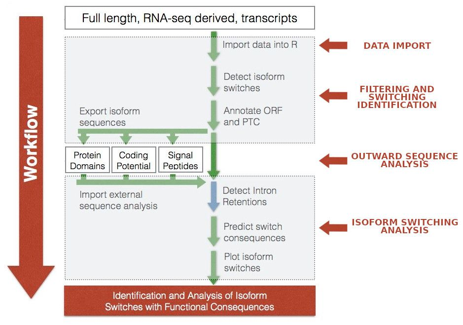

IsoformSwitchAnalyzeRWorkflow

There are three high-level less-customizable wrapper functions:

1. `isoformSwitchAnalysisPart1()`
2. `isoformSwitchAnalysisPart2()`
3. `isoformSwitchAnalysisCombined()`

## Exercise #1

1. Can you use the vignette or the help/manual of the functions (i.e. `?isoformSwitchAnalysisPart1()` after loading the package) to summarize what steps they are performing?

**Solution**

- `isoformSwitchAnalysisPart1()` - Identifying isoform switches, annotating ORF, preparing sequences to use external tools if required (check out the [vignette](https://www.bioconductor.org/packages/release/bioc/vignettes/IsoformSwitchAnalyzeR/inst/doc/IsoformSwitchAnalyzeR.html#:~:text=in%20Figure%201.-,Part,-1%20Extract%20Isoform) for details).
- `isoformSwitchAnalysisPart2()` - Analyzing alternative splicing, predicting functional consequences, plotting.
- `isoformSwitchAnalysisCombined()` - If one does not plan to incorporate external sequence analysis (or is only interested in splicing), it is possible to run the full workflow using this function.

Alternatively, we are going to be using a step-by-step approach so we can analyze the transcript counts from our previous workbooks and discuss results.

## Importing the data

First, we are loading the package and importing the data:

```r
# Installation from the Bioconductor repository:
# First install Bioconductor
# if (!requireNamespace("BiocManager", quietly = TRUE)){
#     install.packages("BiocManager")
#     BiocManager::install()
# }
# Then install the package:
# BiocManager::install("IsoformSwitchAnalyzeR")

# Looading the package:
suppressPackageStartupMessages(library(IsoformSwitchAnalyzeR))

# Importing the data:
# From the vignette:
# salmonQuant <- importIsoformExpression(
#    parentDir = system.file("extdata/",package="IsoformSwitchAnalyzeR")
# )

# There are alternatives, merged samples, different subdirectories, etc! Again, always a good idea to do ?importIsoformExpression and checking out the full vignette.

# Tip: Many packages and vignettes use small subsets of data as examples, which may be included in internal folders such as "extdata". We are using our data here, but when you are on your own, it may be a good idea to double check a package/workflow is working as expected with the test dataset before using real data.
countsDirectoryToUse <- "~/work/gse154927-full/kallisto"

kallistoFilePaths <- list.files(path=countsDirectoryToUse, pattern="*.txt", full.names=T)
kallistoQuant <- importIsoformExpression(sampleVector=kallistoFilePaths)
```

```
Step 1 of 3: Identifying which algorithm was used...
```

```
    The quantification algorithm used was: Kallisto
```

```
Step 2 of 3: Reading data...
```

```
Note: importing `abundance.h5` is typically faster than `abundance.tsv`
```

```
reading in files with read_tsv
```

```
1 2 3 4 5 6 7 8 9 10 11 12 13 14 15 16
Step 3 of 3: Normalizing abundance values (not counts) via edgeR...
Done
```

Next, let’s take a closer look. What have we imported?

```r
class(kallistoQuant)
```

```
[1] "list"
```

```r
head(kallistoQuant$abundance, 5)
```

```
       isoform_id HCT116_EpCAMhigh_1 HCT116_EpCAMhigh_2 HCT116_EpCAMhigh_3
1 ENST00000641515          0.0000000          0.0000000          0.0000000
2 ENST00000426406          0.0000000          0.2010359          0.2567546
3 ENST00000332831          0.0000000          0.2010359          0.2567546
4 ENST00000616016          0.4313932          0.2801056          0.1444433
5 ENST00000618323          0.1711923          0.3660362          0.2706446
  HCT116_EpCAMhigh_4 HCT116_EpCAMlow_1 HCT116_EpCAMlow_2 HCT116_EpCAMlow_3
1          0.0000000         0.0000000      0.000000e+00        0.00000000
2          0.0000000         0.3820347      0.000000e+00        0.03022812
3          0.0000000         0.3820347      0.000000e+00        0.03022812
4          0.2569020         0.3520601      1.130644e+00        0.57618159
5          0.4802698         0.0000000      1.445995e-07        0.00000000
  HCT116_EpCAMlow_4 SW480_EpCAMhigh_1 SW480_EpCAMhigh_2 SW480_EpCAMhigh_3
1        0.00000000                 0       0.000000000        0.04588622
2        0.00000000                 0       0.000000000        0.00000000
3        0.00000000                 0       0.000000000        0.00000000
4        0.10592793                 0       0.010409862        0.00000000
5        0.05139535                 0       0.003306059        0.00000000
  SW480_EpCAMhigh_4 SW480_EpCAMlow_1 SW480_EpCAMlow_2 SW480_EpCAMlow_3
1                 0      0.000000000                0       0.00000000
2                 0      0.053443973                0       0.01786231
3                 0      0.053443973                0       0.01786231
4                 0      0.033395089                0       0.00000000
5                 0      0.009414677                0       0.00000000
  SW480_EpCAMlow_4
1       0.03533789
2       0.10635338
3       0.10635338
4       0.00000000
5       0.00000000
```

```r
head(kallistoQuant$counts, 5)
```

```
       isoform_id HCT116_EpCAMhigh_1 HCT116_EpCAMhigh_2 HCT116_EpCAMhigh_3
1 ENST00000641515           0.000000           0.000000           0.000000
2 ENST00000426406           0.000000           8.752337           4.921035
3 ENST00000332831           0.000000           8.752337           4.921035
4 ENST00000616016           9.449062          12.194730           2.768444
5 ENST00000618323           3.749726          15.935822           5.187256
  HCT116_EpCAMhigh_4 HCT116_EpCAMlow_1 HCT116_EpCAMlow_2 HCT116_EpCAMlow_3
1           0.000000          0.000000      0.000000e+00         0.0000000
2           0.000000          5.077354      0.000000e+00         0.6575607
3           0.000000          5.077354      0.000000e+00         0.6575607
4           5.575887          4.678982      4.665808e+01        12.5338374
5          10.423937          0.000000      5.967161e-06         0.0000000
  HCT116_EpCAMlow_4 SW480_EpCAMhigh_1 SW480_EpCAMhigh_2 SW480_EpCAMhigh_3
1         0.0000000                 0         0.0000000         0.7973496
2         0.0000000                 0         0.0000000         0.0000000
3         0.0000000                 0         0.0000000         0.0000000
4         1.3953778                 0         0.3794058         0.0000000
5         0.6770257                 0         0.1204952         0.0000000
  SW480_EpCAMhigh_4 SW480_EpCAMlow_1 SW480_EpCAMlow_2 SW480_EpCAMlow_3
1                 0        0.0000000                0        0.0000000
2                 0        1.2292456                0        0.3068881
3                 0        1.2292456                0        0.3068881
4                 0        0.7681084                0        0.0000000
5                 0        0.2165436                0        0.0000000
  SW480_EpCAMlow_4
1        0.8587309
2        2.5844480
3        2.5844480
4        0.0000000
5        0.0000000
```

## Exercise #2

1. What R object is created by the `importIsoformExpression` function?
2. Even in comprehensive vignettes and workbook there may be obscure concepts. Can you investigate what are the differences between the `abundance` and `counts` imported in `IsoformSwitchAnalyzeR`?

**Solution**

1. A list of with 4 elements. These include 3 data.frames and another list.
2. A count is the raw count of reads that have overlapped some genomic feature. Abundance would be a more biologically meaningful quantification of the expression (i.e. the biological process) of a gene or transcript, which has been normalized in some way. Counts are better for the statistical analysis but the abundance estimates are better to measuring effect sizes.

What else is needed?

1. Apart from the Kallisto counts, we will also need some information about the analyses that we want to perform. Similar to the previous session, we need to specify the experimental design matrix, i.e. biologically meaningful comparisons and possible covariates to include in the statistical models if there are unwanted sources of variation not due to experimental conditions you are interested in but that may influence results).
2. Annotation file with transcript structure, which transcripts are known for which genes, coordinates, etc (i.e. GTF file).
3. Nucleotide sequence of the transcripts (FASTA file).

```r
# Matrix design:
myDesign <- data.frame(
  sampleID = colnames(kallistoQuant$abundance)[-1],
  condition = gsub("_[1-4]","",colnames(kallistoQuant$abundance)[-1])
)

# Note that as in differential expression analyses, at least 3 replicates is a must for statistical analyses!

# We also download/locate/prepare:
annotation_file <- "~/work/grch38-p13-gencode-release-42/annotation/genes_protein_coding.gtf"
transcript_sequences <- "~/work/grch38-p13-gencode-release-42/annotation/genes_protein_coding_kallistoIndex/transcripts.fa"
myComparisons <- data.frame(
  condition_1 = c("HCT116_EpCAMhigh", "HCT116_EpCAMlow"),
  condition_2 = c("SW480_EpCAMhigh", "SW480_EpCAMlow")
)
# Note that the quantification that we are importing, annotation file, transcript sequences... must of course share the transcript IDs! Be careful when importing databases! Alternatively, the full vignette contain details on how to analyse de novo isoforms/transcripts.

# An object called switchAnalyzeRlist is going to integrate all of this
aSwitchList <- importRdata(
  isoformCountMatrix = kallistoQuant$counts,
  isoformRepExpression = kallistoQuant$abundance,
  designMatrix = myDesign,
  comparisonsToMake = myComparisons,
  isoformExonAnnoation = annotation_file,
  isoformNtFasta = transcript_sequences
)
```

```
Step 1 of 10: Checking data...
```

```
Step 2 of 10: Obtaining annotation...
```

```
    importing GTF (this may take a while)...
```

```
    21265 ( 12.55%) isoforms were removed since they were not expressed in any samples.
```

```
Step 3 of 10: Fixing StringTie gene annoation problems...
```

```
    There were no need to rescue any annotation
```

```
    18741 genes_id were assigned their original gene_id instead of the StringTie gene_id.
        This was only done when it could be done unambiguous.
```

```
Step 4 of 10: Calculating expression estimates from count data...
```

```
    Skipped as user supplied expression via the "isoformRepExpression" argument...
```

```
Step 5 of 10: Testing for unwanted effects...
```

```
    Added 3 batch/covariates to the design matrix
```

```
Step 6 of 10: Batch correcting expression estimates...
```

```
Step 7 of 10: Extracting data from each condition...
```

```
Step 8 of 10: Making comparisons...
```

```
Step 9 of 10: Making switchAnalyzeRlist object...
```

```
Step 10 of 10: Guestimating differential usage...
```

```
    The GUESSTIMATED number of genes with differential isoform usage are:
```

```
                           comparison estimated_genes_with_dtu
1 HCT116_EpCAMhigh vs SW480_EpCAMhigh               967 - 1612
2   HCT116_EpCAMlow vs SW480_EpCAMlow              1425 - 2374
```

```
Done
```

```r
summary(aSwitchList)
```

```
This switchAnalyzeRlist list contains:
 148137 isoforms from 18732 genes
 2 comparison from 4 conditions (in total 16 samples)

Feature analyzed:
[1] "ORFs, ntSequence"
```

## Exercise #3

1. Check out the resources used! How much GB of RAM is your R session using? In real analyses, the availability of computational resources is often a problem and something to keep in mind!
2. How many isoforms have been quantified and how many genes are represented?
3. How many isoforms were not expressed in any sample?

**Solution**

1. It will depend on whether this is a new session, whether you have kept old objects, have freed unused objects, etc… but you may notice that the objects in this analyses are bigger than in the previous ones!
2. 148,137 isoforms from 18,732 genes
3. 21,265 isoforms

## Filtering

Your `switchAnalyzeRlist` will most likely contain genes and isoforms that are irrelevant and should be filtered out. The function in charge of this is `preFilter`.

```r
aSwitchList <- preFilter(
  switchAnalyzeRlist = aSwitchList,
  geneExpressionCutoff = 1,
  isoformExpressionCutoff = 0,
  removeSingleIsoformGenes = TRUE
)
```

```
The filtering removed 61037 ( 41.2% of ) transcripts. There is now 87100 isoforms left
```

## Exercise #4

1. Check out the manual of the function documentation (help) and the full vignette if required. Which aspects could your filter on?
2. Can you think about any other way of filtering?
3. How many transcripts were removed?

**Solution**

1. Multi-isoform genes, gene expression, isoform expression, isoform fraction (isoform usage), unwanted isoform classes, unwanted gene biotypes, genes without differential isoform usage.
2. There may be non-used isoforms that only appear here because they were in the isoform/gene annotation used… We could filter here, or remove them from the annotation in previous steps, so they are not even quantified!
3. More than 40% of them! 61,037 transcripts.

## Computing Isoform Switches

There are different approaches supported in `IsoformSwitchAnalyzeR`. We are using `DEXSeq`. This is a step that would take long and exhaust the computational resources of this session. Therefore we will subsample the data and proceed with only a subset of our data:

```r
# Subsampling, so we only get results with higher differential isoform fraction and the object is not that big anymore
aSwitchList_sub <- subsetSwitchAnalyzeRlist(
  switchAnalyzeRlist = aSwitchList,
  subset = abs(aSwitchList$isoformFeatures$dIF) > 0.15
)

# We can also clean up the old one!
rm(aSwitchList); rm(kallistoQuant); gc()
```

```
           used  (Mb) gc trigger   (Mb)  max used   (Mb)
Ncells 11602835 619.7   34389758 1836.7  34389758 1836.7
Vcells 68624078 523.6  207847468 1585.8 207844897 1585.8
```

```r
# Note that we need to think about two parameters before computing switches:
alpha <- 0.05 # FDR corrected P-value (Q-value) cutoff
dIFcutoff <- 0.10 #  minimum (absolute) change in isoform usage (dIF) to be considered (effect size)

aSwitchList_sub <- isoformSwitchTestDEXSeq(
  switchAnalyzeRlist = aSwitchList_sub,
  reduceToSwitchingGenes=FALSE,
  alpha=alpha,
  dIFcutoff = dIFcutoff,
  onlySigIsoforms = FALSE
)
```

```
Step 1 of 2: Testing each pairwise comparisons with DEXSeq (this might be a bit slow)...
```

```
    Estimated run time is: 3.9 min
```

```
Step 2 of 2: Integrating result into switchAnalyzeRlist...
```

```
    Isoform switch analysis was performed for 5117 gene comparisons (100%).
```

```
Total runtime: 1.33 min
```

```
Done
```

```r
# Get some numbers
extractSwitchSummary(aSwitchList_sub)
```

```
                           Comparison nrIsoforms nrSwitches nrGenes
1 HCT116_EpCAMhigh vs SW480_EpCAMhigh        649        490     358
2   HCT116_EpCAMlow vs SW480_EpCAMlow       1866       1150     897
3                            Combined       2157       1414    1039
```

```r
table_top_10 <- extractTopSwitches(
  aSwitchList_sub,
  filterForConsequences = FALSE,
  n=10,
  inEachComparison = TRUE
)

table_top_10
```

```
            gene_ref gene_id gene_name      condition_1     condition_2
1  geneComp_00006707    GUSB      GUSB HCT116_EpCAMhigh SW480_EpCAMhigh
2  geneComp_00013670    RPSA      RPSA HCT116_EpCAMhigh SW480_EpCAMhigh
3  geneComp_00000480  AKAP12    AKAP12 HCT116_EpCAMhigh SW480_EpCAMhigh
4  geneComp_00008981  MAGED1    MAGED1 HCT116_EpCAMhigh SW480_EpCAMhigh
5  geneComp_00005713    FLNA      FLNA HCT116_EpCAMhigh SW480_EpCAMhigh
6  geneComp_00005744     FN1       FN1 HCT116_EpCAMhigh SW480_EpCAMhigh
7  geneComp_00013926 SCGB3A2   SCGB3A2 HCT116_EpCAMhigh SW480_EpCAMhigh
8  geneComp_00008592   LIMA1     LIMA1 HCT116_EpCAMhigh SW480_EpCAMhigh
9  geneComp_00013132    RBP1      RBP1 HCT116_EpCAMhigh SW480_EpCAMhigh
10 geneComp_00010805   OBSL1     OBSL1 HCT116_EpCAMhigh SW480_EpCAMhigh
11 geneComp_00032402    RPSA      RPSA  HCT116_EpCAMlow  SW480_EpCAMlow
12 geneComp_00029537   OBSL1     OBSL1  HCT116_EpCAMlow  SW480_EpCAMlow
13 geneComp_00019212  AKAP12    AKAP12  HCT116_EpCAMlow  SW480_EpCAMlow
14 geneComp_00023008   DNMBP     DNMBP  HCT116_EpCAMlow  SW480_EpCAMlow
```

[output cut: 27 more lines]

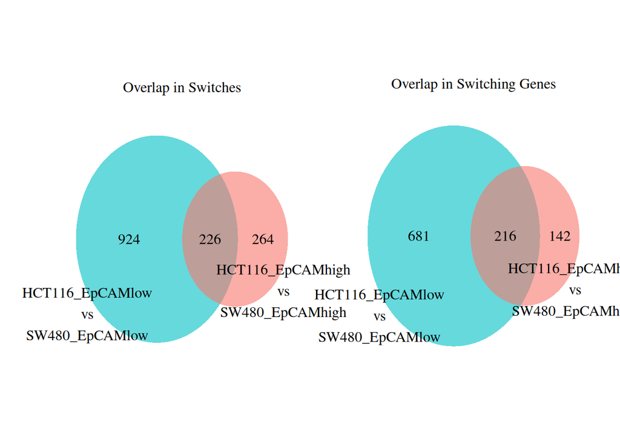

```r
extractSwitchOverlap(
  aSwitchList_sub,
  filterForConsequences=FALSE,
  plotIsoforms = FALSE
)
```

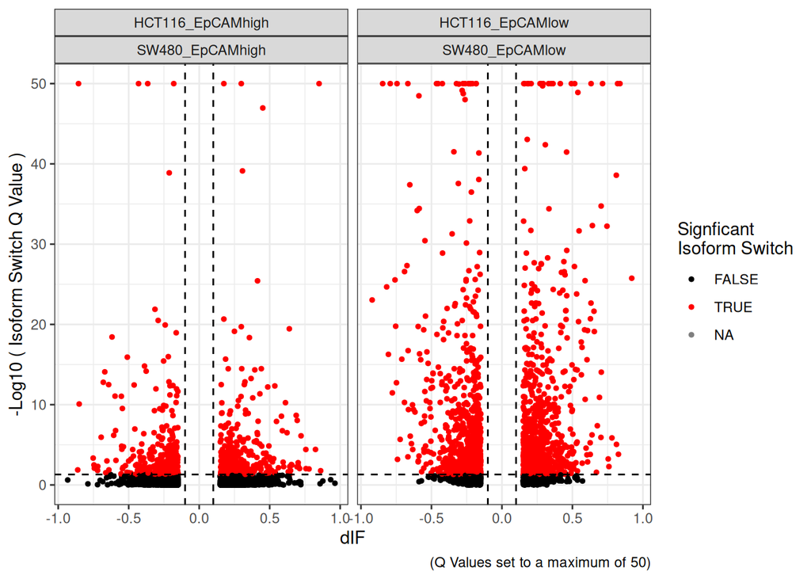

```r
# Get nice Volcano plots to visualise differences
datToPlot <- aSwitchList_sub$isoformFeatures
minPValToPlot <- 1E-50

datToPlot$isoform_switch_q_value <- ifelse(datToPlot$isoform_switch_q_value < minPValToPlot, minPValToPlot, datToPlot$isoform_switch_q_value)

ggplot(data=datToPlot, aes(x=dIF, y=-log10(isoform_switch_q_value))) +
  geom_point(
    aes( color=abs(dIF) > 0.1 & isoform_switch_q_value < 0.05 ), # default cutoff
    size=1
  ) +
  geom_hline(yintercept = -log10(0.05), linetype='dashed') + # default cutoff
  geom_vline(xintercept = c(-0.1, 0.1), linetype='dashed') + # default cutoff
  facet_wrap( ~ condition_1 ~ condition_2) +
  #facet_grid(condition_1 ~ condition_2) + # alternative to facet_wrap if you have overlapping conditions
  scale_color_manual('Signficant\nIsoform Switch', values = c('black','red')) +
  labs(x='dIF', y='-Log10 ( Isoform Switch Q Value )',
       caption=sprintf("(Q Values set to a maximum of %s)", -log10(minPValToPlot))) +
  theme_bw()
```

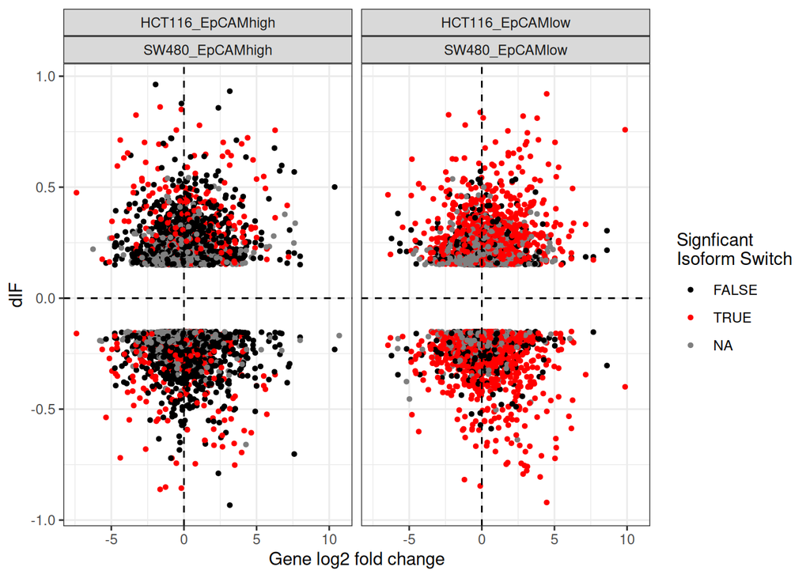

```r
# Take into account the gene-level fold change too
ggplot(data=aSwitchList_sub$isoformFeatures, aes(x=gene_log2_fold_change, y=dIF)) +
  geom_point(
    aes( color=abs(dIF) > 0.1 & isoform_switch_q_value < 0.05 ), # default cutoff
    size=1
  ) +
  facet_wrap( ~ condition_1 ~ condition_2) +
  #facet_grid(condition_1 ~ condition_2) + # alternative to facet_wrap if you have overlapping conditions
  geom_hline(yintercept = 0, linetype='dashed') +
  geom_vline(xintercept = 0, linetype='dashed') +
  scale_color_manual('Signficant\nIsoform Switch', values = c('black','red')) +
  labs(x='Gene log2 fold change', y='dIF') +
  theme_bw()
```

## Exercise #5

1. How many isoform switches have we detected in total? Corresponding to how many genes?
2. How many gene comparisons were tested?
3. Which is the gene with the switch considered to be ‘top’?
4. How many overlapping genes are shared between comparisons?

## Computing alternative splicing

Since the gene/exon structure is known, alternative splicing can be identified. In this package, alternative splicing is used as a term which covers: Alternative Splicing (AS), Alternative Transcription Start Sites (ATSS, sometimes called alternative first exon), and Alternative Transcription Termination Sites (ATTS, sometimes called alternative last exon).

```r
aSwitchList_sub <- analyzeAlternativeSplicing(
  switchAnalyzeRlist = aSwitchList_sub
)
```

```
Step 1 of 3: Massaging data...
```

```
Step 2 of 3: Analyzing splicing...
```

```
Step 3 of 3: Preparing output...
```

```
Done
```

```r
tibble::as_tibble(head(aSwitchList_sub$AlternativeSplicingAnalysis, 10))
```

```
# A tibble: 10 × 25
   isoform_id         ES ES_genomic_start ES_genomic_end   MEE MEE_genomic_start
   <chr>           <dbl> <chr>            <chr>          <dbl> <chr>
 1 ENST00000483026     1 42718246         42718586           0 <NA>
 2 ENST00000647439     0 <NA>             <NA>               0 <NA>
 3 ENST00000205557     1 16220273         16220388           0 <NA>
 4 ENST00000576204     0 <NA>             <NA>               0 <NA>
 5 ENST00000577103     0 <NA>             <NA>               0 <NA>
 6 ENST00000683808     0 <NA>             <NA>               0 <NA>
 7 ENST00000684614     0 <NA>             <NA>               0 <NA>
 8 ENST00000315713     0 <NA>             <NA>               0 <NA>
 9 ENST00000370214     1 94478524         94478723           0 <NA>
10 ENST00000554566     0 <NA>             <NA>               0 <NA>
# ℹ 19 more variables: MEE_genomic_end <chr>, MES <dbl>,
#   MES_genomic_start <chr>, MES_genomic_end <chr>, IR <dbl>,
#   IR_genomic_start <chr>, IR_genomic_end <chr>, A5 <dbl>,
#   A5_genomic_start <chr>, A5_genomic_end <chr>, A3 <dbl>,
#   A3_genomic_start <chr>, A3_genomic_end <chr>, ATSS <dbl>,
#   ATSS_genomic_start <chr>, ATSS_genomic_end <chr>, ATTS <dbl>,
#   ATTS_genomic_start <chr>, ATTS_genomic_end <chr>
```

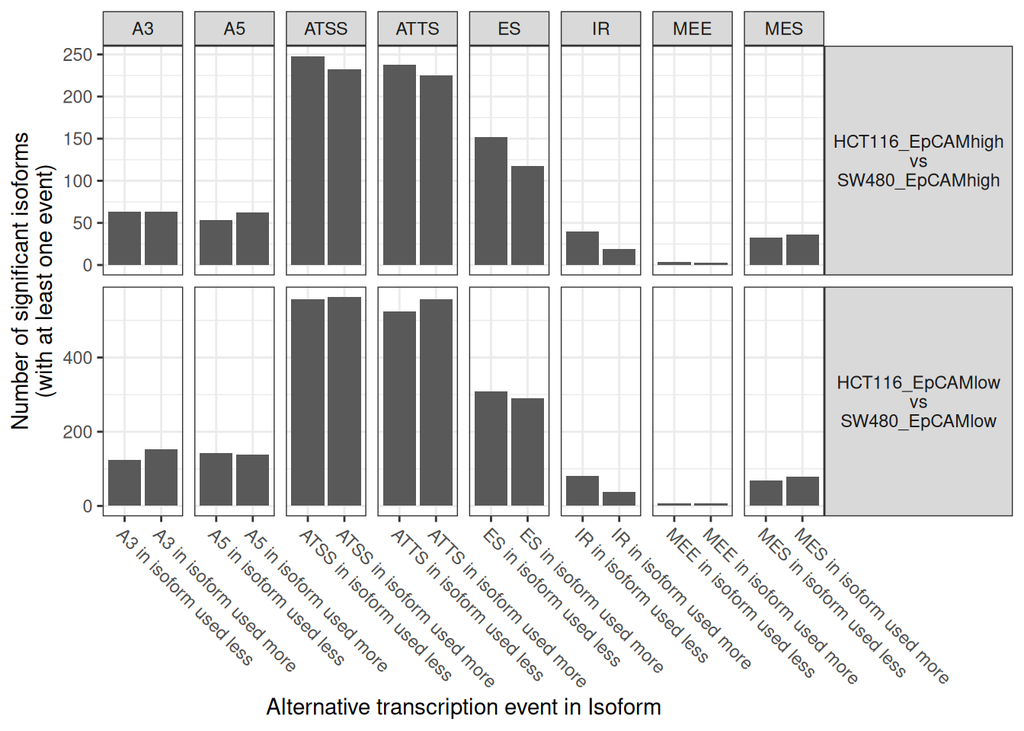

```r
extractSplicingSummary(aSwitchList_sub)
```

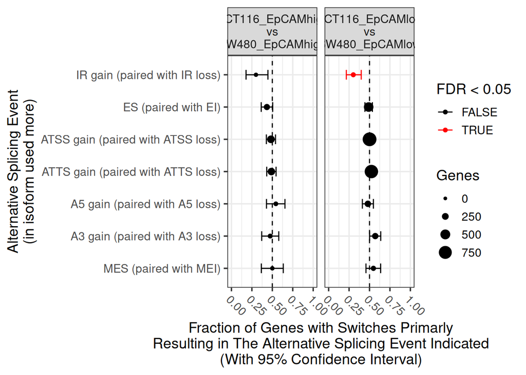

```
        condition_1     condition_2                            AStype nUp nDown
1  HCT116_EpCAMhigh SW480_EpCAMhigh     A3 gain (paired with A3 loss)  45    50
2  HCT116_EpCAMhigh SW480_EpCAMhigh     A5 gain (paired with A5 loss)  44    37
3  HCT116_EpCAMhigh SW480_EpCAMhigh ATSS gain (paired with ATSS loss) 156   167
4  HCT116_EpCAMhigh SW480_EpCAMhigh ATTS gain (paired with ATTS loss) 151   158
5  HCT116_EpCAMhigh SW480_EpCAMhigh               ES (paired with EI)  88   115
6  HCT116_EpCAMhigh SW480_EpCAMhigh     IR gain (paired with IR loss)  15    35
7  HCT116_EpCAMhigh SW480_EpCAMhigh   MEE gain (paired with MEE loss)   1     2
8  HCT116_EpCAMhigh SW480_EpCAMhigh             MES (paired with MEI)  29    29
9   HCT116_EpCAMlow  SW480_EpCAMlow     A3 gain (paired with A3 loss) 122    92
10  HCT116_EpCAMlow  SW480_EpCAMlow     A5 gain (paired with A5 loss) 107   116
11  HCT116_EpCAMlow  SW480_EpCAMlow ATSS gain (paired with ATSS loss) 407   406
12  HCT116_EpCAMlow  SW480_EpCAMlow ATTS gain (paired with ATTS loss) 410   374
13  HCT116_EpCAMlow  SW480_EpCAMlow               ES (paired with EI) 234   244
14  HCT116_EpCAMlow  SW480_EpCAMlow     IR gain (paired with IR loss)  32    74
```

[output cut: 36 more lines]

```r
extractSplicingEnrichment(aSwitchList_sub, splicingToAnalyze='all')
```

## Exercise #6

1. Which splicing events can we capture? (Hint: see column names of `aSwitchList_sub$AlternativeSplicingAnalysis`, `?analyzeAlternativeSplicing`, labels of the plot…
2. Table manipulations (of data.frames matrices) are crucial when working with omics datasets and interrogating results in R. Choose two splicing events and report how many have we detected checking out the table results.
3. What would the `onlySwitchingGenes` parameter in the `analyzeAlternativeSplicing` function do? Is there anything unusual in the manual page?
4. Is there type of splicing event significantly enriched?

### Solution

1. ES, MEE, MES, IR, A5, A3, ATSS, ATTS
2. Will depend on your choice, but one of:
- ES-793
- MEE-20
- MES-208
- IR-167
- A5-387
- A3-372
- ATSS-1,485
- ATTS- 1,433
3. Only genes with isoform switches would be included (filtering by the parameters `alpha` and `dIFcutoff`). The default value is `TRUE` but the documentation incorrectly claims it’s `FALSE`!
4. Yes! IR in the second comparison

## Predicting potential consequences

Changes in isoform usage may have important functional consequences. Depending on the information that we have gathered in the workflow above, can we try and predict some consequences?

```r
consequencesOfInterest <- c("intron_retention") # The only thing that we can compute

aSwitchList_sub <- analyzeSwitchConsequences(aSwitchList_sub, consequencesToAnalyze = consequencesOfInterest, dIFcutoff = 0.4)
```

```
Step 1 of 4: Extracting genes with isoform switches...
```

```
Step 2 of 4: Analyzing 70 pairwise isoforms comparisons...
```

```
Step 3 of 4: Massaging isoforms comparisons results...
```

```
Step 4 of 4: Preparing output...
```

```
Identified  genes with containing isoforms switching with functional consequences...
```

```r
extractSwitchSummary(aSwitchList_sub, dIFcutoff = 0.4, filterForConsequences = TRUE)
```

```
                           Comparison nrIsoforms nrSwitches nrGenes
1 HCT116_EpCAMhigh vs SW480_EpCAMhigh          7          5       4
2   HCT116_EpCAMlow vs SW480_EpCAMlow         10          5       5
3                            Combined         14          8       7
```

```r
extractSwitchSummary(aSwitchList_sub, dIFcutoff = 0.4, filterForConsequences = FALSE)
```

```
                           Comparison nrIsoforms nrSwitches nrGenes
1 HCT116_EpCAMhigh vs SW480_EpCAMhigh        130         37     100
2   HCT116_EpCAMlow vs SW480_EpCAMlow        227         51     178
3                            Combined        285         70     221
```

## Exercise #7

1. Why can we only choose intron_retention here?
2. How many genes with isoform switches have potential functional consequences based on the differences in intron retention?

### Solution

1. Because for the sake of time we skipped some steps were we would have added more information to the `switchAnalyzeRlist`, executing external software. These could have included others aspects such as coding potential, protein domains, prediction of intrinsically disordered regions, etc.
2. 7 out of 221 genes with switches with a dIF > 0.4.

## Interrogating particular genes

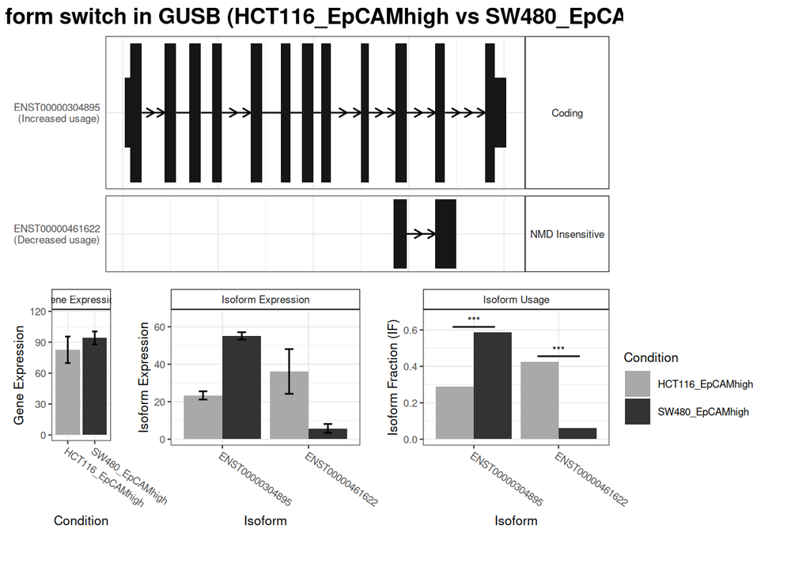

```r
switchPlot(
  aSwitchList_sub,
  gene="GUSB",
  condition1 = "SW480_EpCAMhigh",
  condition2 = "HCT116_EpCAMhigh",
  plotTopology=FALSE
)
```